# PML_ExcercisePrediction

dgg

December 25, 2015

## Background

Using devices such as Jawbone Up, Nike FuelBand, and Fitbit it is now possible to collect a large amount of data about personal activity relatively inexpensively. These type of devices are part of the quantified self movement â€“ a group of enthusiasts who take measurements about themselves regularly to improve their health, to find patterns in their behavior, or because they are tech geeks. One thing that people regularly do is quantify how much of a particular activity they do, but they rarely quantify how well they do it. In this project, your goal will be to use data from accelerometers on the belt, forearm, arm, and dumbell of 6 participants. They were asked to perform barbell lifts correctly and incorrectly in 5 different ways. More information is available from the website here: http://groupware.les.inf.puc-rio.br/har (see the section on the Weight Lifting Exercise Dataset).

## Assignment

We are to create a model to predict the manner in which the subjects performed the exercise.This is the “classe” variable in the training set. We will then use the model to predict 20 different test cases.

## Load and Prepare Training Data

Load required libraries

```r
library(caret)
library(rpart)
```

```r
library(rpart.plot)
trainData <- read.csv("C:\\Projects\\Coursera\\Practical Machine Learning\\Project\\pml-training.csv", na.strings = c("NA", ""))
```

Preliminary investigation and evaluation of the data:

```r
# str(trainData)
# summary(trainData)
```

We can remove several variables that provide no useful data, such as the test subject (‘user_name’), formatted date (‘cvtd_timestamp’ - this data is a factor that will be generated from the raw time stamp variables), and row number (‘X’)

```r
newIndex <- grep("X|user_name|cvtd_timestamp", names(trainData))
trainData <- trainData[, -newIndex]
```

We will remove variables that have virtually no variance as they would not provide significant meaningful information for making an accurate prediction model.

```r
nzData <- nearZeroVar(trainData)
trainData <- trainData[, -nzData]
```

There are a number of variables that are relatively incomplete in that they have a large number of ’NA’s. Removing these will help in making a more accurate predicting model.

```r
naData <- apply(trainData, 2, function(x) {
    sum(is.na(x))
})
trainData <- trainData[, which(naData == 0)]
```

## Cross Validation

For the purposes of cross validation We subset the resulting data into a training set and test set (p=.75)

```r
subIndex <- createDataPartition(y = trainData$classe, p = 0.75, list = FALSE)
trainSubData <- trainData[subIndex, ]
testSubData <- trainData[-subIndex, ]  # cross validation test set
```

Try a Decision Tree predicting model

```r
dcModel <- rpart(classe ~ ., data=trainSubData, method="class")
```

Generate Prediction

```r
dcPrediction <- predict(dcModel, testSubData, type = "class")
```

Plot Prediction

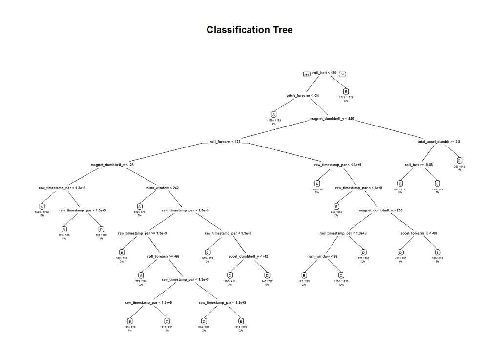

```r
rpart.plot(dcModel, main="Classification Tree", extra=102, under=TRUE, faclen=0)
```

Run model against our subsetted test data

```r
confusionMatrix(dcPrediction, testSubData$classe)
```

```
## Confusion Matrix and Statistics
##
##           Reference
## Prediction    A    B    C    D    E
##          A 1311  105   12   37   57
##          B   37  688   34   13   68
##          C    2   31  730   38   59
##          D   39   63   31  663   74
##          E    6   62   48   53  643
##
## Overall Statistics
##
##                Accuracy : 0.8228
##                  95% CI : (0.8118, 0.8334)
##     No Information Rate : 0.2845
##     P-Value [Acc > NIR] : < 2.2e-16
##
##                   Kappa : 0.7753
##  Mcnemar's Test P-Value : < 2.2e-16
##
## Statistics by Class:
##
##                      Class: A Class: B Class: C Class: D Class: E
## Sensitivity            0.9398   0.7250   0.8538   0.8246   0.7137
## Specificity            0.9399   0.9616   0.9679   0.9495   0.9578
## Pos Pred Value         0.8614   0.8190   0.8488   0.7621   0.7919
## Neg Pred Value         0.9752   0.9358   0.9691   0.9650   0.9370
## Prevalence             0.2845   0.1935   0.1743   0.1639   0.1837
## Detection Rate         0.2673   0.1403   0.1489   0.1352   0.1311
## Detection Prevalence   0.3104   0.1713   0.1754   0.1774   0.1656
## Balanced Accuracy      0.9398   0.8433   0.9108   0.8871   0.8357
```

This model generates pretty good results. 82% accuracy etc.

Next we try the Random Forest approach

```r
library(randomForest)
rfmodel <- randomForest(classe ~. , data=trainSubData, method="class")

rfPrediction <- predict(rfmodel, testSubData, type = "class")

confusionMatrix(rfPrediction, testSubData$classe)
```

```
## Confusion Matrix and Statistics
##
##           Reference
## Prediction    A    B    C    D    E
##          A 1395    1    0    0    0
##          B    0  948    0    0    0
##          C    0    0  854    1    0
##          D    0    0    1  803    0
##          E    0    0    0    0  901
##
## Overall Statistics
##
##                Accuracy : 0.9994
##                  95% CI : (0.9982, 0.9999)
##     No Information Rate : 0.2845
##     P-Value [Acc > NIR] : < 2.2e-16
##
##                   Kappa : 0.9992
##  Mcnemar's Test P-Value : NA
##
## Statistics by Class:
##
##                      Class: A Class: B Class: C Class: D Class: E
## Sensitivity            1.0000   0.9989   0.9988   0.9988   1.0000
## Specificity            0.9997   1.0000   0.9998   0.9998   1.0000
## Pos Pred Value         0.9993   1.0000   0.9988   0.9988   1.0000
## Neg Pred Value         1.0000   0.9997   0.9998   0.9998   1.0000
## Prevalence             0.2845   0.1935   0.1743   0.1639   0.1837
## Detection Rate         0.2845   0.1933   0.1741   0.1637   0.1837
## Detection Prevalence   0.2847   0.1933   0.1743   0.1639   0.1837
## Balanced Accuracy      0.9999   0.9995   0.9993   0.9993   1.0000
```

Now let us predict against our testing set

```r
# run data cleaning processes against the original test set

newIndex <- grep("X|user_name|cvtd_timestamp", names(testData))
testData <- testData[, -newIndex]
nzData <- nearZeroVar(testData)
testData <- testData[, -nzData]

naData <- apply(testData, 2, function(x) {
    sum(is.na(x))
})
testData <- testData[, which(naData == 0)]
```

Run the prediction against the test data

```r
prediction <- predict(rfmodel, testData, type="class")
prediction
```

```
##  1  2  3  4  5  6  7  8  9 10 11 12 13 14 15 16 17 18 19 20
##  B  A  B  A  A  E  D  B  A  A  B  C  B  A  E  E  A  B  B  B
## Levels: A B C D E
```

Now write out the files for project credit

```r
# Write files for submission
pml_write_files = function(x){
  n = length(x)
  for(i in 1:n){
    filename = paste0("problem_id_",i,".txt")
    write.table(x[i],file=filename,quote=FALSE,row.names=FALSE,col.names=FALSE)
  }
}

pml_write_files(prediction)
```